# Report on the Frequency and Impact of Bird-Aircraft Collisions in the US_2026_b

## Analysis of the Frequency and Impact of Bird-Aircraft Collisions in The United States

Project by Paola Vizcarra

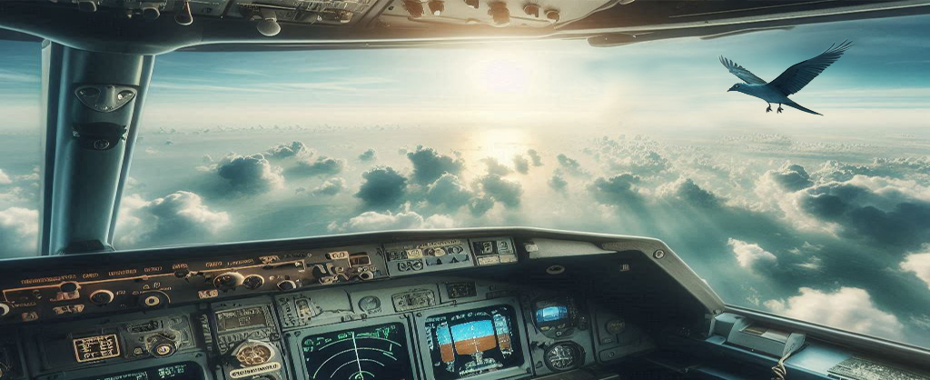

Image generated using Microsoft Bing Image Creator (2024)

## **Report Summary**

1. Setup
   - Import Libraries
2. Dataset Overview
   - Name and Source
   - Purpose
3. Structure and Composition
   - Size:
   - Features
4. Key Insights from Summary Statistics
   - Numerical Variables
   - Categorical Variables
5. Data Quality Assessment
   - Missing Data
   - Balanced Data
   - Duplicates
   - Outliers
6. Patterns and Relationships
   1. FlightPhase, Altitude - Features
   2. Pilots Warned - Feature
   3. Engine - Feature
   4. ConditionsPrecipitation - Feature
   5. MakeModel - Feature
   6. NumberStruckActual - Feature
   7. FlightDate - Feature
   8. OriginState - Feature
   9. Cost - Feature¶
   10. PeopleInjured - Feature
7. Limitations and Challenges
   - Data Gaps
   - Constraints
8. Applications and Relevance
   - Research Questions
   - Potential Use Cases

## **1. Setup**

Go to Top

## **2. Dataset Overview**

Go to Top

### **Name and Source**

This report uses the “Bird Strikes in Aviation: Aircraft Collisions” dataset from Kaggle.com at https://www.kaggle.com/datasets/iamtapendu/bird-strike-by-aircafts-data

### **Purpose**

In aviation, one notable risk is bird strikes—collisions between aircraft and birds or other wildlife. These incidents have become more worrisome due to urban expansion and rising air traffic. Bird strikes can cause substantial damage to aircraft, particularly jet engines, and have been associated with fatal accidents. This analysis seeks to deepen our understanding of transportation safety by examining these risks.

## **3. Structure and Composition**

Go to Top

### **Size:**

```
Shape of data is : (25429, 26)
```

The shape of the dataset is (25429, 26) meaning it contains 25429 rows and 26 columns. Each row has information about a bird-aircraft collision, totaling 25429 incidents.

### **Features**

```
<class 'pandas.core.frame.DataFrame'>
RangeIndex: 25429 entries, 0 to 25428
Data columns (total 26 columns):
 #   Column                    Non-Null Count  Dtype
---  ------                    --------------  -----
 0   RecordID                  25429 non-null  int64
 1   AircraftType              25429 non-null  object
 2   AirportName               25429 non-null  object
 3   AltitudeBin               25429 non-null  object
 4   MakeModel                 25429 non-null  object
 5   NumberStruck              25429 non-null  object
 6   NumberStruckActual        25429 non-null  int64
 7   Effect                    2078 non-null   object
 8   FlightDate                25429 non-null  object
 9   Damage                    25429 non-null  object
```

[output cut: 18 more lines]

### Information about the dataset

1. The output elements are as follows:
   - Column: the name of the column
   - Non-null Count: how many non-null values are found in the column
   - Dtype: the type of value data type of each column ( int64 = int value, object = string value, bool = boolean Y/N)
2. In the "Effect" column, there are 2078 non-null values, meaning there are 23351 null values. Since this accounts for only 8.17% of the occurrences. This feature can be dropped from the model.
3. The "ConditionsPrecipitation" column has only 2015 non-null values. But, although the 92.08% of values are missing, we might still analyze this feature as it might serve to deduct how weather interplays in bird-aircraft collisions.
4. The column "Engines" has 25195 non-null values, meaning only 0.92% of the values are missing. Options to handle missing data include:
   - Use the "AircraftType" column to search and gather the missing information from another source
   - Drop the rows with missing values
   - Replace the missing values with the feature's median.

   Later we'll decide which is more appropriate for this analysis.
5. The "OriginState" column contains only 449 null values. However, upon reviewing the data, it was found that values in uppercase represent locations outside the United States. Since the scope of this analysis only includes the U.S. both types of occurances will be dropped.
6. The "Remarks" column also has null values, but this column has no pertinent information. It will be dropped for this analysis.
7. The remaining columns do not have any null values.
8. The column "WildlifeSpecies" has no null values, but over 50% of the data is classified as "Unknown" (*see count below. Column will be dropped.
9. Not all features contain pertinent data, the following are the features that will be considered in the model:
   - int64(4): NumberStruckActual, Altitude, and PeopleInjured
   - object(15): AirportName, AltitudeBin, MakeModel, FlightDate, Damage, Engines, OriginState, FlightPhase, WildlifeSize, ConditionsSky, PilotWarned, Cost
10. Object type will be converted from strings into numbers, as machine learning algorithms require numerical data to function.

#### *Column "WildlifeSpecies": count "unknown" values

```
The string "unknown" appears 15586 times, meaning that 61.29% of the values lack useful information.
```

## **4. Key Insights**

Go to Top

|  | RecordID | AircraftType | AirportName | AltitudeBin | MakeModel | NumberStruck | NumberStruckActual | Effect | FlightDate | Damage | ... | RemainsSentToSmithsonian | Remarks | WildlifeSize | ConditionsSky | WildlifeSpecies | PilotWarned | Cost | Altitude | PeopleInjured | IsAircraftLarge? |
| --- | --- | --- | --- | --- | --- | --- | --- | --- | --- | --- | --- | --- | --- | --- | --- | --- | --- | --- | --- | --- | --- |
| 0 | 202152 | Airplane | LAGUARDIA NY | (1000, 2000] | B-737-400 | Over 100 | 859 | Engine Shut Down | 11/23/00 0:00 | Caused damage | ... | False | FLT 753. PILOT REPTD A HUNDRED BIRDS ON UNKN T... | Medium | No Cloud | Unknown bird - medium | N | 30,736 | 1500 | 0 | Yes |
| 1 | 208159 | Airplane | DALLAS/FORT WORTH INTL ARPT | (-1, 0] | MD-80 | Over 100 | 424 | NaN | 7/25/01 0:00 | Caused damage | ... | False | 102 CARCASSES FOUND. 1 LDG LIGHT ON NOSE GEAR ... | Small | Some Cloud | Rock pigeon | Y | 0 | 0 | 0 | No |
| 2 | 207601 | Airplane | LAKEFRONT AIRPORT | (30, 50] | C-500 | Over 100 | 261 | NaN | 9/14/01 0:00 | No damage | ... | False | FLEW UNDER A VERY LARGE FLOCK OF BIRDS OVER AP... | Small | No Cloud | European starling | N | 0 | 50 | 0 | No |
| 3 | 215953 | Airplane | SEATTLE-TACOMA INTL | (30, 50] | B-737-400 | Over 100 | 806 | Precautionary Landing | 9/5/02 0:00 | No damage | ... | False | NOTAM WARNING. 26 BIRDS HIT THE A/C, FORCING A... | Small | Some Cloud | European starling | Y | 0 | 50 | 0 | Yes |
| 4 | 219878 | Airplane | NORFOLK INTL | (30, 50] | CL-RJ100/200 | Over 100 | 942 | NaN | 6/23/03 0:00 | No damage | ... | False | NO DMG REPTD. | Small | No Cloud | European starling | N | 0 | 50 | 0 | No |

5 rows × 26 columns

### Name of Columns

```
Index(['RecordID', 'AircraftType', 'AirportName', 'AltitudeBin', 'MakeModel',
       'NumberStruck', 'NumberStruckActual', 'Effect', 'FlightDate', 'Damage',
       'Engines', 'Operator', 'OriginState', 'FlightPhase',
       'ConditionsPrecipitation', 'RemainsCollected?',
       'RemainsSentToSmithsonian', 'Remarks', 'WildlifeSize', 'ConditionsSky',
       'WildlifeSpecies', 'PilotWarned', 'Cost', 'Altitude', 'PeopleInjured',
       'IsAircraftLarge?'],
      dtype='object')
```

### Variable Description and Category of Features:

**Categorical/Nominal:** These features describe qualities or labels with no inherent order:

- AircraftType: Identifies the type of aircraft.
- AirportName: Specifies the airport's name.
- MakeModel: Manufacturer and model of the aircraft.
- Operator: The airline managing the aircraft.
- OriginState: U.S. state where the flight started.
- FlightPhase: Describes the stage of flight (e.g., takeoff, landing).
- WildlifeSize: Classifies the size of the bird(s).
- WildlifeSpecies: Identifies the bird species.
- ConditionsSky: Describes sky conditions during the incident.
- ConditionsPrecipitation: Indicates precipitation conditions.
- Damage: Description of the type of damage.
- Remarks: Additional notes or comments.

**Binary:** These features have two possible values (e.g., "Yes"/"No"):

- Effect: Whether the incident caused damage.
- RemainsCollected?: Indicates if remains were collected.
- RemainsSentToSmithsonian: If remains were sent for analysis.
- PilotWarned: If the pilot was alerted about potential bird strikes.
- IsAircraftLarge?: Whether the aircraft is classified as large.

**Ordinal:** These features have categories with a meaningful order or rank:

- AltitudeBin: Grouped altitude ranges, indicating height in increasing levels.

**Continuous:** These are numeric features with an infinite number of possible values:

- Cost: The financial cost of the incident.
- Altitude: The precise altitude (in feet) during the incident.

**Count:** These features represent whole numbers or counts:

- NumberStruck: Estimated count of birds struck.
- NumberStruckActual: Actual count of birds struck.
- Engines: Total number of engines involved in the incident.
- PeopleInjured: Number of individuals injured during the incident.

### **Numerical Variables**

#### Retrieve information about the numerical features.

|  | RecordID | NumberStruckActual | Altitude | PeopleInjured |
| --- | --- | --- | --- | --- |
| count | 25429.000000 | 25429 | 25429.000000 | 25429 |
| mean | 253800.148767 | 3 | 799.028432 | 0 |
| std | 38472.800499 | 13 | 1740.079843 | 0 |
| min | 1195.000000 | 1 | 0.000000 | 0 |
| 25% | 225742.000000 | 1 | 0.000000 | 0 |
| 50% | 248609.000000 | 1 | 50.000000 | 0 |
| 75% | 269044.000000 | 1 | 700.000000 | 0 |
| max | 321909.000000 | 942 | 18000.000000 | 6 |

#### Finding the Confidence Interval for the mean of Numeric Values

```
95% Confidence Intervals for Numerical Columns:
Confidence Interval for NumberStruckActual: [2.542, 2.857]
Confidence Interval for Altitude: [777.641, 820.416]
```

#### Visualize incidents in relation to Altitude

##### Uni-variate Analysis

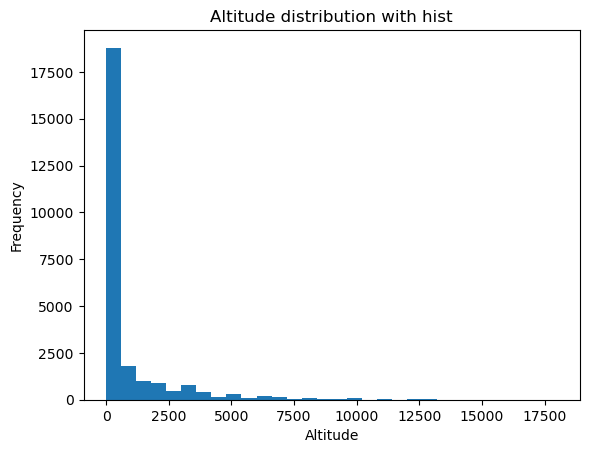

### **Categorical Variables**

#### Finding the Confidence Interval for the mean of Categorical Values

```
Proportions and 95% Confidence Intervals for Categorical Values:
No damage: Proportion = 0.903, CI = [0.900, 0.907]
Caused damage: Proportion = 0.097, CI = [0.093, 0.100]
```

## **5. Data Quality Assessment**

Go to Top

### **Missing Data**

```
RecordID                        0
AircraftType                    0
AirportName                     0
AltitudeBin                     0
MakeModel                       0
NumberStruck                    0
NumberStruckActual              0
Effect                      23351
FlightDate                      0
Damage                          0
Engines                       234
Operator                        0
OriginState                   449
FlightPhase                     0
ConditionsPrecipitation     23414
RemainsCollected?               0
RemainsSentToSmithsonian        0
Remarks                      4761
WildlifeSize                    0
ConditionsSky                   0
WildlifeSpecies                 0
PilotWarned                     0
Cost                            0
Altitude                        0
PeopleInjured                   0
IsAircraftLarge?                0
dtype: int64
```

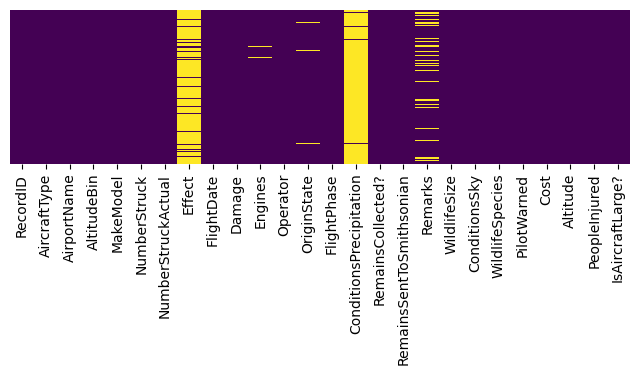

#### Observations:

The findings reinforce what was discussed before:

1. Columns "Effect" and "ConditionsPrecipitation" have over 90% missing values. "Effect" feature will be dropped.
2. In column "Remarks" approximately only 19% of the values are null, but as seen before, the information in this column is not pertinent to this analysis.
3. As for "Engines" and "OriginState", rows containing null on unusable values will be dealt accordingly.

### **Balanced Data**

Get information about balanced or imbalanced data sets which may affect the preprocessing or algorithm.

#### Damage - Feature

```
['Caused damage' 'No damage']
```

```
Damage
No damage        22975
Caused damage     2454
Name: count, dtype: int64
```

```
Damage
No damage        90.349601
Caused damage     9.650399
Name: count, dtype: float64
```

#### Observations:

Of 25429 incidents, 2454 caused damage, accounting for only 9.65% of the data. This indicates a strong imbalance.

### **Duplicates**

#### WildlifeSpecies and WildlifeSize - Features:

```
             WildlifeSpecies WildlifeSize
0      Unknown bird - medium       Medium
1                Rock pigeon        Small
2          European starling        Small
3          European starling        Small
4          European starling        Small
...                      ...          ...
25424                Mallard       Medium
25425   Unknown bird - large        Large
25426           Tree swallow        Small
25427  Unknown bird - medium       Medium
25428        Red-tailed hawk       Medium

[25429 rows x 2 columns]
```

The WildlifeSpecies feature indicates the animal species involved in the incident and sometimes includes information about its size. WildlifeSize provides only the size of the animal involved. Due to this, it would be safe to either ignore 'WildlifeSpecies' (since we see later that many fields have "Unknown" as a description) or extract the pertinent data.

### **Outliers**

#### Cost - Features:

Prepare "Cost" data for analysis.

- Clean data by removing commas
- Create new column "CostAsFloat" with converted data.

[figure not shown]

```
float64
```

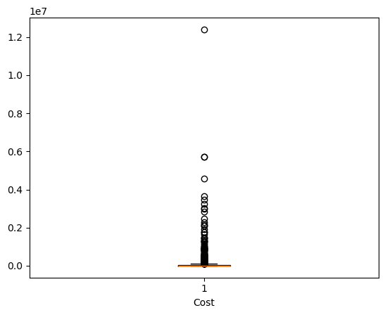

Note that in certain situations, as we see here, outliers should not be removed. When the data is highly skewed, extreme values may be representative of the distribution's tail. Removing them could lead to a loss of valuable information.

- Over 20000 of the incidents caused no damage, while less than 5000 did caused damage. Reiterates the infoermations seen above.

## **6. Patterns and Relationships**

Go to Top

Analyzing dataset features:

### A. FlightPhase, Altitude - Features

Visualize the relationship between Altitude and FlightPhase

Countplot

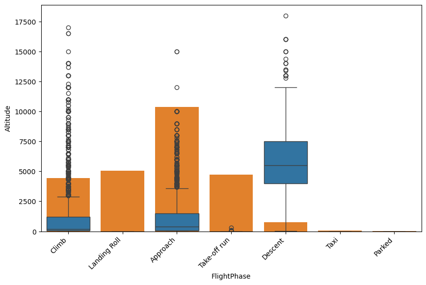

#### Observations:

- Over 10000 incidents happened during Approach, which is when the aircraft aligns with the runway and prepares to land.
- Above 4000 incidents took place at each of the following phases: Climb, Landing Roll, and Take-off run.
- Although not many, incidents happened during the Parking and Taxi phases.

##### Plot the Heatmap

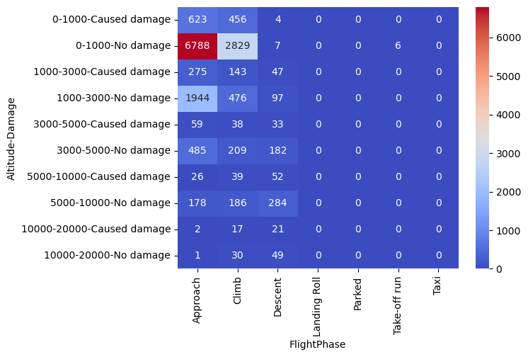

##### Visualize count in Flight Phase and Altitude levels (both are linked)

```
FlightPhase   Damage
Approach      Caused damage     985
              No damage        9397
Climb         Caused damage     694
              No damage        3735
Descent       Caused damage     157
              No damage         619
Landing Roll  Caused damage     236
              No damage        4811
Parked        Caused damage       2
              No damage           8
Take-off run  Caused damage     376
              No damage        4335
Taxi          Caused damage       4
              No damage          70
dtype: int64
```

[figure not shown]

##### Show how Damage is distributed across Flight Phase

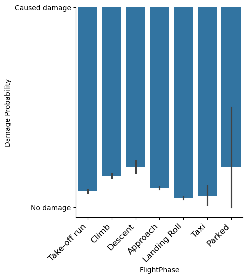

Show how Damage is distributed across Altitude

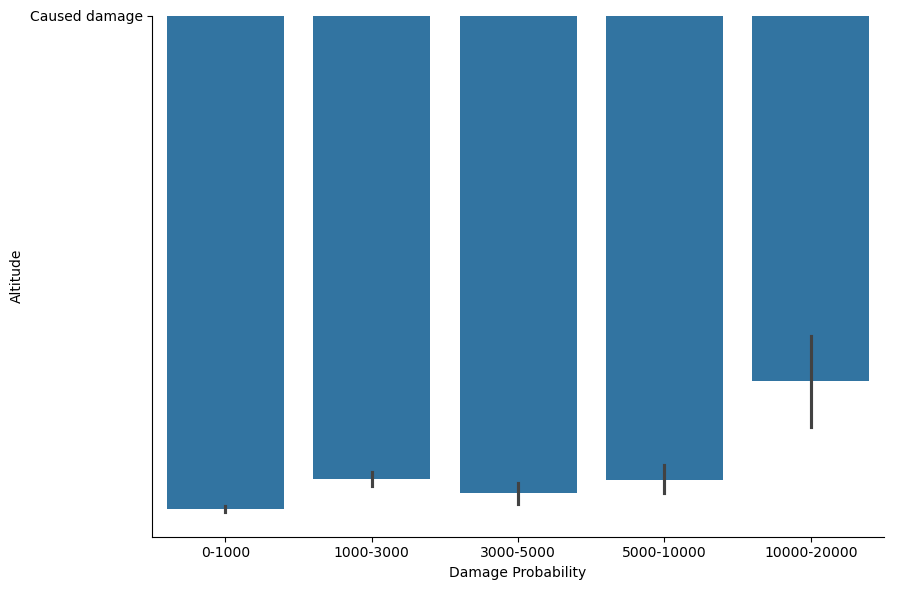

##### Pie chart displaying the proportion of incidents at each Flight Phase

```
array(['Climb', 'Landing Roll', 'Approach', 'Take-off run', 'Descent',
       'Taxi', 'Parked'], dtype=object)
```

[figure not shown]

### B. Pilots Warned - Feature

[figure not shown]

[figure not shown]

Explore the counts of PilotWarned and Damage

```
    FlightYear PilotWarned         Damage  Counts
0         2000           N  Caused damage     146
1         2000           N      No damage     789
2         2000           Y  Caused damage      50
3         2000           Y      No damage     382
4         2001           N  Caused damage      88
5         2001           N      No damage     707
6         2001           Y  Caused damage      35
7         2001           Y      No damage     400
8         2002           N  Caused damage     123
9         2002           N      No damage     976
10        2002           Y  Caused damage      63
11        2002           Y      No damage     519
12        2003           N  Caused damage     117
13        2003           N      No damage     889
```

[output cut: 34 more lines]

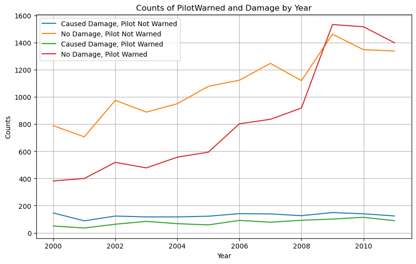

#### **Correlation**

For incidents that did not cause damage, the number of incidents when the pilot was warned was significantly lower before 2009. In contrast, for incidents causing damage, there was no substantial difference between the incidents when the pilot was warned and when they were not.

### C. Engine - Feature

- Engine feature contains null values. These will be filled with the median, or the most frequent value.

```
2
```

Visualize the distribution, we'll remove null values.

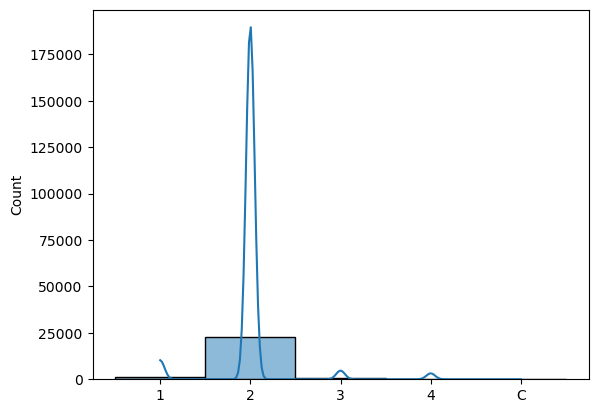

#### Faceted plot, each plot corresponds to a different subset of the data based on the "Engine" column.

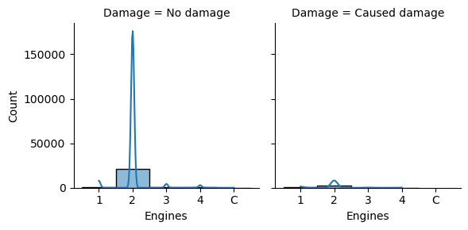

#### Plotting Probability Density Functions (PDFs) for 'Engines' based on the 'Damage' column

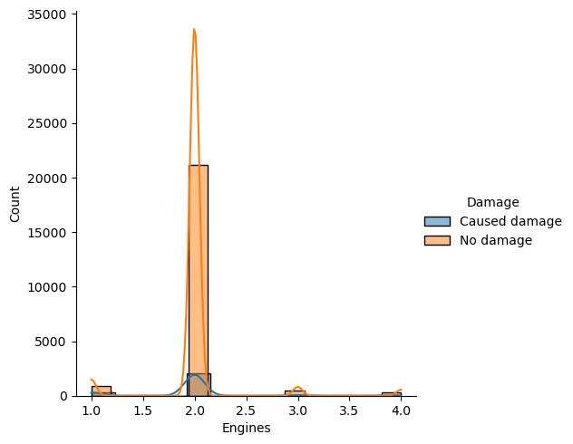

#### Violin plot

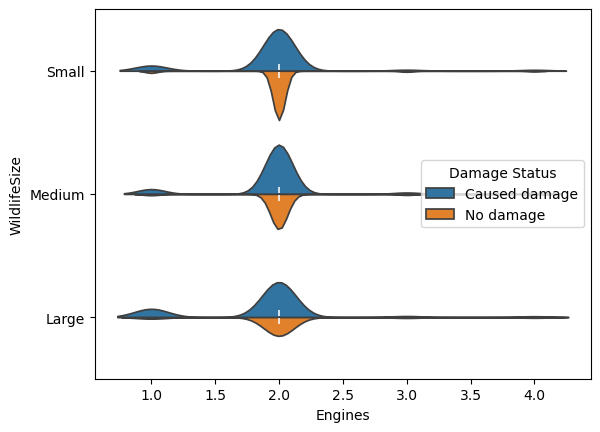

```
NumberStruckActual      1      2      3      4      5      6      7      8    \
Damage
Caused damage        1789.0   71.0   61.0   63.0   69.0   57.0   63.0   66.0
No damage           19001.0  396.0  408.0  420.0  467.0  406.0  432.0  392.0

NumberStruckActual    9      10   ...  99   100  227  261  320  424  537  806  \
Damage                            ...
Caused damage        66.0   68.0  ...  NaN  NaN  1.0  NaN  1.0  1.0  NaN  NaN
No damage           421.0  393.0  ...  4.0  1.0  NaN  1.0  NaN  NaN  1.0  1.0

NumberStruckActual  859  942
Damage
Caused damage       1.0  NaN
No damage           NaN  1.0

[2 rows x 106 columns]

PeopleInjured        0    1    2    6
Damage
Caused damage   2441.0  9.0  3.0  1.0
No damage      22975.0  NaN  NaN  NaN

IsAircraftLarge?     No   Yes
Damage
Caused damage      1850   604
No damage         15177  7798
```

#### Observations:

1. NumberStruckActual: Most incidents had only 1 actual struck.
2. PeopleInjured - Here we see that in 13 events people were injured.
3. IsAircraftLarge? - Most incidents with no damage involved smaller aircraft. Large aircraft, have a higher count in the non-damaging incidents but are involved less in the damaging incidents.

#### Bi-variate analysis

Box Plot

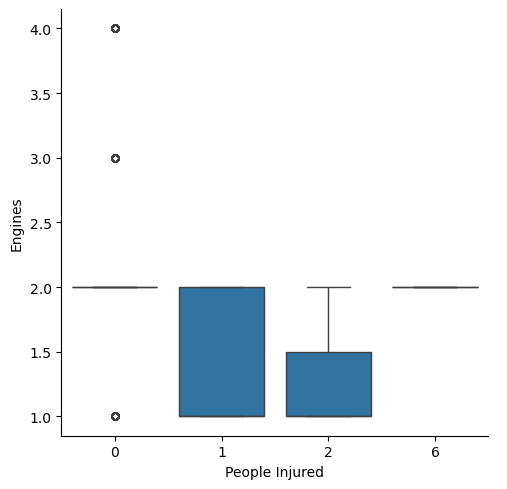

The number of engines is not a factor to be considered for people getting ingured.

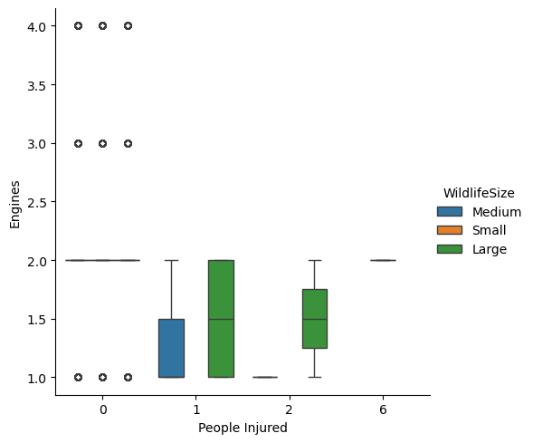

The number of engines did not appear to affect the number of people injured. While it seems that larger wildlife sizes had a greater impact on 1-engine aircraft, we know that in the incident where 6 people were injured, small wildlife was involved. Additionally, the number of incidents with injured people is not large enough to draw definitive conclusions (Fortunately, there have not been many dangerous incidents).

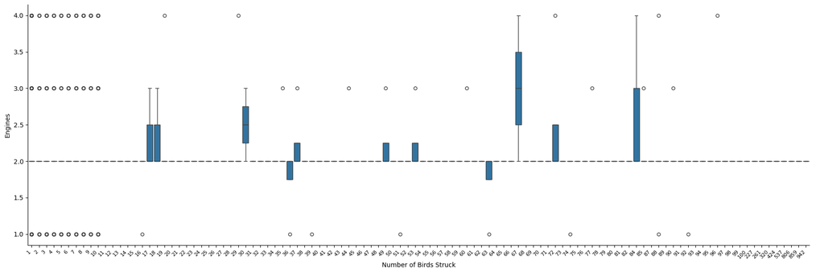

There does not seem to be a relation within how different amount of birds struck damage engines, as the incidents with high amounts of birds were not many.

#### Observations:

1. Most of the incidents involved 2 engine aircraft.
2. Of those incidents, most did not result in damages.
3. As for aircraft with 1, 3, and 4 engines, the difference between the resulting damage/no damage was not as great.
4. Interestingly, the violin plot shows that when the incident involved a 2-engine aircraft and resulted in damage, medium-sized wildlife caused similar damage than the large size.

#### **Correlation**

The data shows weak correlations overall, with some indications that 2-engine aircraft are involved in more incidents, and larger aircraft are less likely to experience damaging incidents.

#### **Trend**

The trend suggests that two-engine aircraft have been involved in a higher number of incidents.

Note: This could imply that two-engine aircraft are more prone to incidents, or it could be that there are simply more of these aircraft in existence, leading to a higher number of incidents.

### D. ConditionsPrecipitation - Feature

Note that this feature contains only 2,015 non-null values, so the analysis is preliminary and should be interpreted with caution

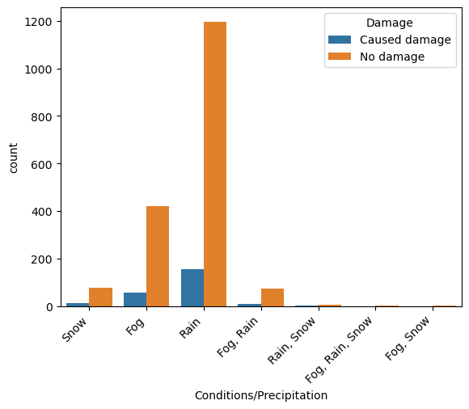

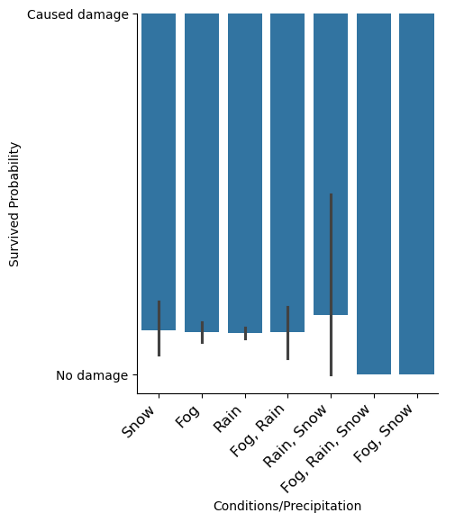

#### Observations:

1. Although the sample data is limited, it provides a reasonable insight into how weather impacts bird-aircraft collision occurrences.2.
2. Most incidents occurred during "Rain", although most did not result in damages.
3. During "Rain, Snow" conditions, incidents were more likely to cause damage; however, these conditions accounted for only a small number of occurrences.

#### **Trend**

Rain increases the frequency of bird-aircraft collisions, but these incidents are generally less likely to cause damage. However, when rain and snow conditions are present, incidents are more likely to result in damage, although these conditions occur less frequently.

### E. MakeModel - Feature

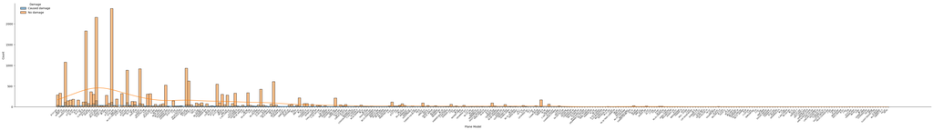

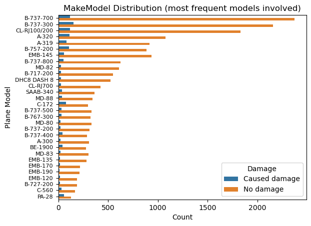

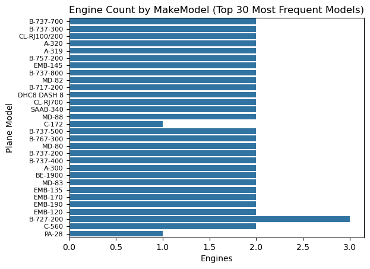

#### Observations:

1. Among all the models involved in bird-aircraft collisions, only a small number experienced repeated incidents.
2. Aircraft model B-737-700 (2-engine) had the most incidents.
3. As seen before, most of the models involved in incidents had 2 engines.

#### **Trend**

The trend indicates a strong association between the number of engines and the likelihood of involvement in collision.

Note: As stated before, this could imply that two-engine aircraft are more prone to incidents, or it could be that there are simply more of these aircraft in existence, leading to a higher number of incidents.

### F. NumberStruckActual - Feature

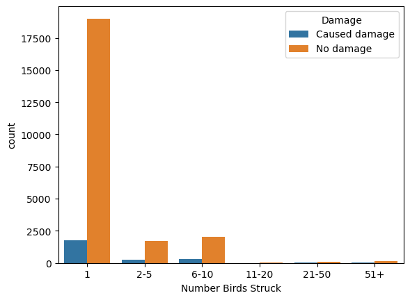

##### Pie chart to visualize the distribution of the number of birds struck on a single incident

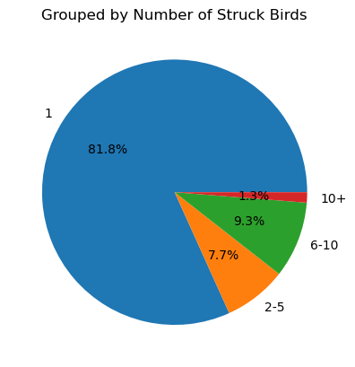

#### Multivariate analysis

Correlation Between NumberStruckActual, Damage, Engines, IsAircraftLarge? and PeopleInjured

```
Damage
No damage        22975
Caused damage     2454
Name: count, dtype: int64
```

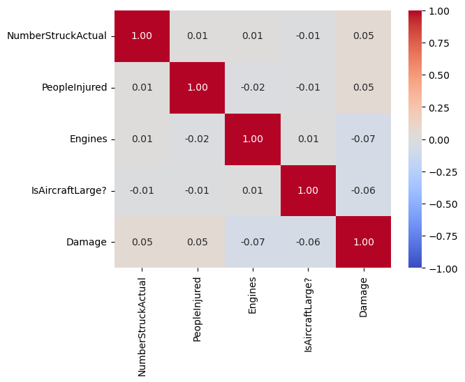

The inference we can draw from this table is:

[output not shown]

```
            Engines  IsAircraftLarge?  NumberStruckActual  PeopleInjured
Damage
No Damage  2.011665          0.339412            2.485745       0.000000
Damage     1.931540          0.246129            4.702119       0.008557
```

#### Observations:

1. Over 80% of incidents implied only one bird.
2. The vast majority of incidents where there was only one bird involved,did not cused damage.
3. Overall ost incidents did not caused damage.

#### **Trend**

The data show that most incidents implied only one bird.

### G. FlightDate - Feature

Explore Trends Over Time: Yearly distribution of bird strike incidents. We need to group FlightDate column by year

|  | RecordID | AircraftType | AirportName | AltitudeBin | MakeModel | NumberStruck | NumberStruckActual | Effect | FlightDate | Damage | ... | ConditionsSky | WildlifeSpecies | PilotWarned | Cost | Altitude | PeopleInjured | IsAircraftLarge? | CostAsFloat | FlightYear | NumberStruckBinned |
| --- | --- | --- | --- | --- | --- | --- | --- | --- | --- | --- | --- | --- | --- | --- | --- | --- | --- | --- | --- | --- | --- |
| 25424 | 319672 | Airplane | SACRAMENTO INTL | (0, 10] | B-737-700 | 1 | 1 | NaN | 2011-12-29 | 0 | ... | No Cloud | Mallard | Y | 0 | 0-1000 | 0 | 1 | 0.0 | 2011 | 1 |
| 25425 | 321151 | Airplane | REDDING MUNICIPAL | (1000, 2000] | EMB-120 | 1 | 1 | NaN | 2011-12-30 | 0 | ... | Overcast | Unknown bird - large | N | 0 | 1000-3000 | 0 | 0 | 0.0 | 2011 | 1 |
| 25426 | 319677 | Airplane | ORLANDO INTL | (-1, 0] | A-321 | 1 | 1 | NaN | 2011-12-30 | 0 | ... | Some Cloud | Tree swallow | Y | 0 | NaN | 0 | 0 | 0.0 | 2011 | 1 |
| 25427 | 319679 | Airplane | DETROIT METRO WAYNE COUNTY ARPT | (-1, 0] | B-757-200 | 1 | 1 | NaN | 2011-12-31 | 0 | ... | Some Cloud | Unknown bird - medium | Y | 0 | NaN | 0 | 1 | 0.0 | 2011 | 1 |
| 25428 | 319593 | Airplane | ABRAHAM LINCOLN CAPITAL ARPT | (-1, 0] | B-737-400 | 1 | 1 | NaN | 2011-12-31 | 1 | ... | No Cloud | Red-tailed hawk | N | 0 | NaN | 0 | 1 | 0.0 | 2011 | 1 |

5 rows × 29 columns

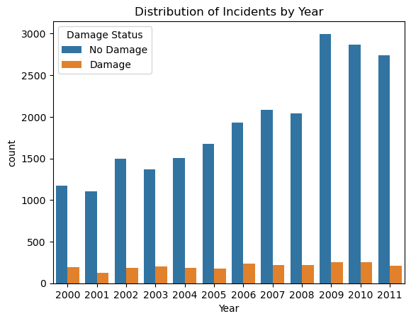

##### Correlation Between Year and Damage

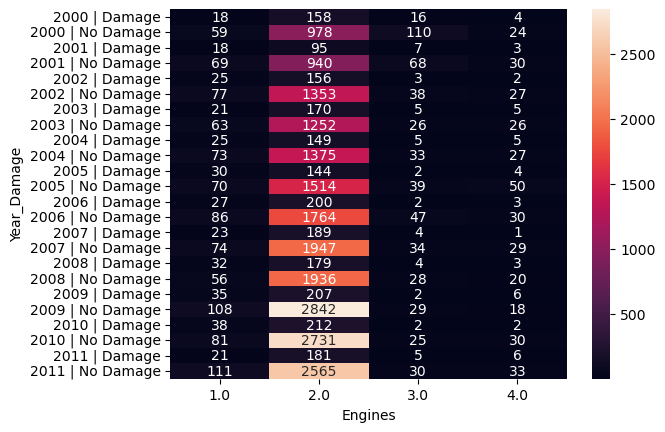